# physiology_stats

Debbie Leung

2/11/2021

## Set up

```r
#install.packages("Hmisc")
library("Hmisc")
```

```r
#install.packages("corrplot")
library(corrplot)
library(dplyr)
library(tidyr)
```

```r
my_data <- read.csv("physiology_cleaned.csv", stringsAsFactors = FALSE) %>% na_if("")
```

Steps: 1. Compute statistical tests 2. Compute normality and homogeneity tests 3. Compute any post-hoc tests for significant results

## Covariables with Covariables

### Correlation Matrix

Problem: cannot lump all continuous variables to display into a correlation matrix because of missing NA values… The matrices computed below removed avg_temp and temp_sd.

```r
con_var_na <- my_data %>% select(shell_length:heart_rate)
test <- cor(con_var_na, use = "complete.obs", method = c("pearson"))
test
```

```
##                     shell_length average_weight weight_before weight_after
## shell_length          1.00000000     0.70127339    0.69882682   0.70356657
## average_weight        0.70127339     1.00000000    0.99987609   0.99987377
## weight_before         0.69882682     0.99987609    1.00000000   0.99949976
## weight_after          0.70356657     0.99987377    0.99949976   1.00000000
## weight_loss           0.05382386     0.28183940    0.29690809   0.26655924
## weight_loss_percent  -0.20152879    -0.09895452   -0.08358567  -0.11444196
## osmolality           -0.04749961     0.03115936    0.03459912   0.02767967
## heart_rate           -0.15731781    -0.20927667   -0.21004996  -0.20844357
##                     weight_loss weight_loss_percent  osmolality  heart_rate
## shell_length         0.05382386         -0.20152879 -0.04749961 -0.15731781
## average_weight       0.28183940         -0.09895452  0.03115936 -0.20927667
## weight_before        0.29690809         -0.08358567  0.03459912 -0.21004996
## weight_after         0.26655924         -0.11444196  0.02767967 -0.20844357
## weight_loss          1.00000000          0.90809698  0.21867101 -0.10769495
## weight_loss_percent  0.90809698          1.00000000  0.20236385 -0.07191950
## osmolality           0.21867101          0.20236385  1.00000000 -0.02903395
## heart_rate          -0.10769495         -0.07191950 -0.02903395  1.00000000
```

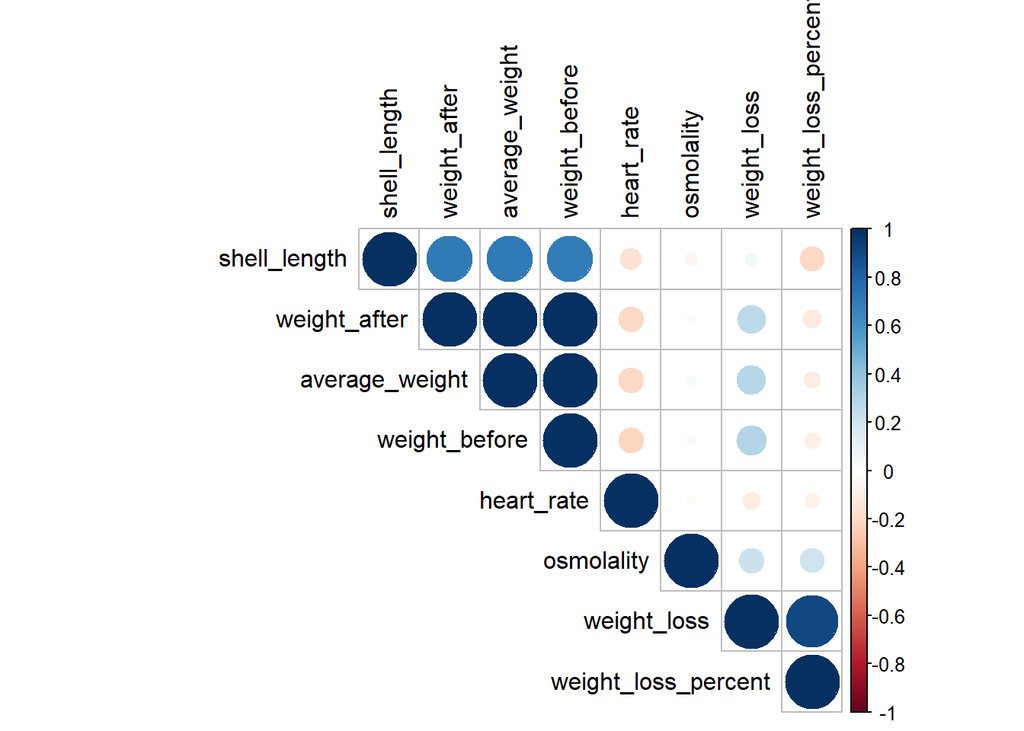

```r
# cannot lump all continuous variables to display into a correlation matrix because of missing NA values... (cut out avg_temp and temp_sd)
con_var <- my_data %>% select(shell_length:heart_rate) %>% drop_na
mydata.cor = cor(con_var, method = c("pearson"))
corrplot(mydata.cor, type = "upper", order = "hclust", tl.col = "black")
```

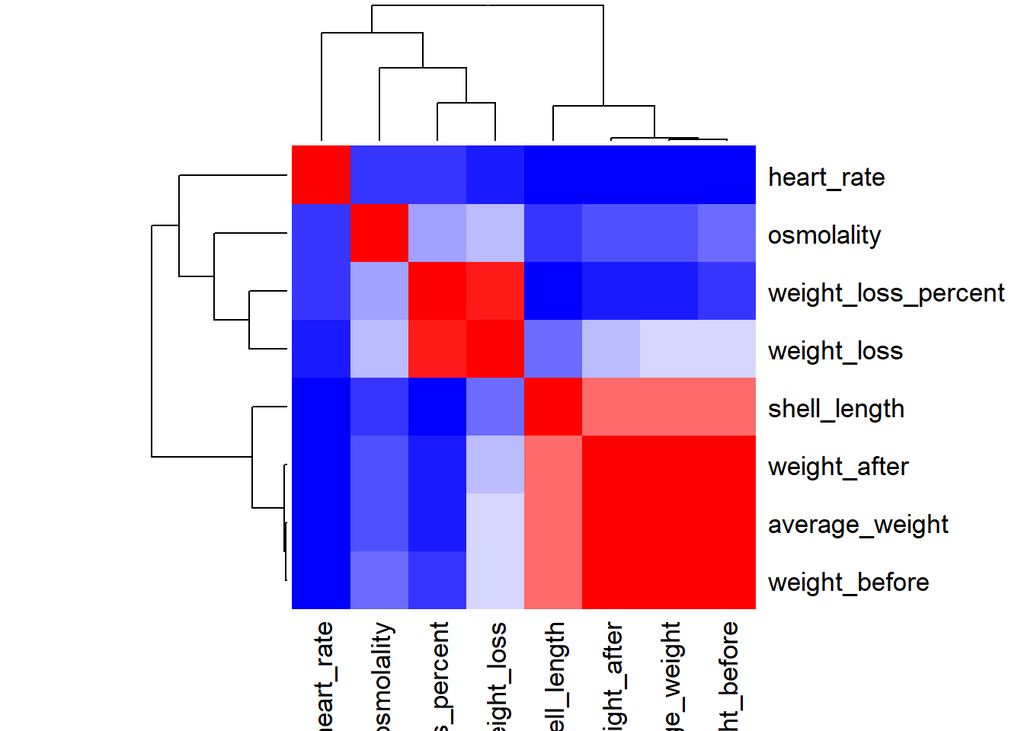

```r
palette = colorRampPalette(c("blue", "white", "red")) (20)
heatmap(x = mydata.cor, col = palette, symm = TRUE)
```

```r
mydata.rcorr = rcorr(as.matrix(con_var))
mydata.rcorr
```

```
##                     shell_length average_weight weight_before weight_after
## shell_length                1.00           0.70          0.70         0.70
## average_weight              0.70           1.00          1.00         1.00
## weight_before               0.70           1.00          1.00         1.00
## weight_after                0.70           1.00          1.00         1.00
## weight_loss                 0.05           0.28          0.30         0.27
## weight_loss_percent        -0.20          -0.10         -0.08        -0.11
## osmolality                 -0.05           0.03          0.03         0.03
## heart_rate                 -0.16          -0.21         -0.21        -0.21
##                     weight_loss weight_loss_percent osmolality heart_rate
## shell_length               0.05               -0.20      -0.05      -0.16
## average_weight             0.28               -0.10       0.03      -0.21
## weight_before              0.30               -0.08       0.03      -0.21
## weight_after               0.27               -0.11       0.03      -0.21
## weight_loss                1.00                0.91       0.22      -0.11
## weight_loss_percent        0.91                1.00       0.20      -0.07
## osmolality                 0.22                0.20       1.00      -0.03
## heart_rate                -0.11               -0.07      -0.03       1.00
##
## n= 67
##
##
## P
##                     shell_length average_weight weight_before weight_after
## shell_length                     0.0000         0.0000        0.0000
## average_weight      0.0000                      0.0000        0.0000
## weight_before       0.0000       0.0000                       0.0000
## weight_after        0.0000       0.0000         0.0000
## weight_loss         0.6653       0.0209         0.0147        0.0292
## weight_loss_percent 0.1020       0.4256         0.5013        0.3564
## osmolality          0.7027       0.8023         0.7810        0.8240
## heart_rate          0.2036       0.0892         0.0880        0.0905
##                     weight_loss weight_loss_percent osmolality heart_rate
## shell_length        0.6653      0.1020              0.7027     0.2036
## average_weight      0.0209      0.4256              0.8023     0.0892
## weight_before       0.0147      0.5013              0.7810     0.0880
## weight_after        0.0292      0.3564              0.8240     0.0905
## weight_loss                     0.0000              0.0754     0.3857
## weight_loss_percent 0.0000                          0.1005     0.5630
## osmolality          0.0754      0.1005                         0.8156
## heart_rate          0.3857      0.5630              0.8156
```

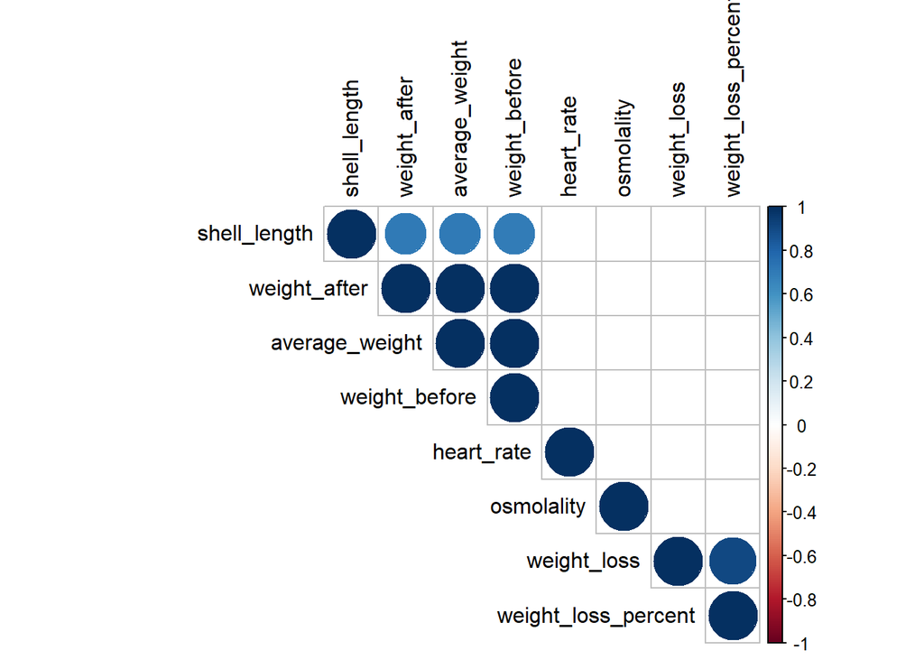

```r
corrplot(mydata.rcorr$r, type="upper", order="hclust", tl.col = "black",
         p.mat = mydata.rcorr$P, sig.level = 0.01, insig = "blank")
```

```r
# ++++++++++++++++++++++++++++
# flattenCorrMatrix
# ++++++++++++++++++++++++++++
# cormat : matrix of the correlation coefficients
# pmat : matrix of the correlation p-values
flattenCorrMatrix <- function(cormat, pmat) {
  ut <- upper.tri(cormat)
  data.frame(
    row = rownames(cormat)[row(cormat)[ut]],
    column = rownames(cormat)[col(cormat)[ut]],
    cor  =(cormat)[ut],
    p = pmat[ut]
    )
}
```

```r
mydata.rcorr = rcorr(as.matrix(con_var))
flattenCorrMatrix(mydata.rcorr$r, mydata.rcorr$P)
```

```
##                    row              column         cor            p
## 1         shell_length      average_weight  0.70127339 3.872769e-11
## 2         shell_length       weight_before  0.69882682 4.833556e-11
## 3       average_weight       weight_before  0.99987609 0.000000e+00
## 4         shell_length        weight_after  0.70356657 3.139977e-11
## 5       average_weight        weight_after  0.99987377 0.000000e+00
## 6        weight_before        weight_after  0.99949976 0.000000e+00
## 7         shell_length         weight_loss  0.05382386 6.653126e-01
## 8       average_weight         weight_loss  0.28183940 2.085521e-02
## 9        weight_before         weight_loss  0.29690809 1.469317e-02
## 10        weight_after         weight_loss  0.26655924 2.922503e-02
## 11        shell_length weight_loss_percent -0.20152879 1.019720e-01
## 12      average_weight weight_loss_percent -0.09895452 4.256294e-01
## 13       weight_before weight_loss_percent -0.08358567 5.012776e-01
## 14        weight_after weight_loss_percent -0.11444196 3.564484e-01
## 15         weight_loss weight_loss_percent  0.90809698 0.000000e+00
## 16        shell_length          osmolality -0.04749961 7.026840e-01
## 17      average_weight          osmolality  0.03115936 8.023466e-01
## 18       weight_before          osmolality  0.03459912 7.810434e-01
## 19        weight_after          osmolality  0.02767967 8.240440e-01
## 20         weight_loss          osmolality  0.21867101 7.543688e-02
## 21 weight_loss_percent          osmolality  0.20236385 1.005305e-01
## 22        shell_length          heart_rate -0.15731781 2.035856e-01
## 23      average_weight          heart_rate -0.20927667 8.919805e-02
## 24       weight_before          heart_rate -0.21004996 8.799555e-02
## 25        weight_after          heart_rate -0.20844357 9.050798e-02
## 26         weight_loss          heart_rate -0.10769495 3.856908e-01
## 27 weight_loss_percent          heart_rate -0.07191950 5.630226e-01
## 28          osmolality          heart_rate -0.02903395 8.155829e-01
```

### Individual Pearson Correlation Tests

```r
cor.test(my_data$average_weight, my_data$shell_length, method = "pearson")
```

```
##
##  Pearson's product-moment correlation
##
## data:  my_data$average_weight and my_data$shell_length
## t = 7.7367, df = 76, p-value = 3.509e-11
## alternative hypothesis: true correlation is not equal to 0
## 95 percent confidence interval:
##  0.5177025 0.7722306
## sample estimates:
##       cor
## 0.6637645
```

Conclude body weight is positively correlated with shell length

```r
#Model_1 <- lmer(trait1 ~ factor1, dataset)
#anova(Model_1, ddf="lme4")
```

### ANOVA

Body weight, shell length, sex and experimental day are not statisically significantly affected.

```r
weight_sex.aov <- aov(average_weight ~ sex, data = my_data)
summary(weight_sex.aov)
```

```
##             Df Sum Sq Mean Sq F value Pr(>F)
## sex          2   8.65   4.325   2.374    0.1
## Residuals   75 136.66   1.822
## 56 observations deleted due to missingness
```

```r
weight_day.aov <- aov(average_weight ~ experimental_day, data = my_data)
summary(weight_day.aov)
```

```
##                  Df Sum Sq Mean Sq F value Pr(>F)
## experimental_day  3   5.93   1.977   1.049  0.376
## Residuals        74 139.39   1.884
## 56 observations deleted due to missingness
```

```r
length_sex.aov <- aov(shell_length ~ sex, data = my_data)
summary(length_sex.aov)
```

```
##              Df Sum Sq Mean Sq F value Pr(>F)
## sex           2   16.5   8.256   1.119   0.33
## Residuals   131  966.3   7.377
```

```r
length_day.aov <- aov(shell_length ~ experimental_day, data = my_data)
summary(length_day.aov)
```

```
##                   Df Sum Sq Mean Sq F value Pr(>F)
## experimental_day   4   31.2   7.796   1.057  0.381
## Residuals        129  951.7   7.377
```

## Covariables with Dependent Variables

### Correlation Tests

Please refer to the correlation matrix above. Below are individual tests for body weight and dependent variables.

```r
#cor(x, method = "pearson", use = "complete.obs")
#weight <- mydata[, c(7,8,12,13,14)] %>% drop_na("osmolality")
```

```r
cor.test(my_data$average_weight, my_data$weight_loss, method = "pearson")
```

```
##
##  Pearson's product-moment correlation
##
## data:  my_data$average_weight and my_data$weight_loss
## t = 2.1999, df = 75, p-value = 0.0309
## alternative hypothesis: true correlation is not equal to 0
## 95 percent confidence interval:
##  0.02351869 0.44560702
## sample estimates:
##       cor
## 0.2462006
```

Average weight is correlated with weight loss!!!

```r
cor.test(my_data$average_weight, my_data$osmolality, method = "pearson")
```

```
##
##  Pearson's product-moment correlation
##
## data:  my_data$average_weight and my_data$osmolality
## t = 0.42417, df = 75, p-value = 0.6727
## alternative hypothesis: true correlation is not equal to 0
## 95 percent confidence interval:
##  -0.1769983  0.2699410
## sample estimates:
##        cor
## 0.04891993
```

```r
cor.test(my_data$average_weight, my_data$heart_rate, method = "pearson")
```

```
##
##  Pearson's product-moment correlation
##
## data:  my_data$average_weight and my_data$heart_rate
## t = -1.8031, df = 67, p-value = 0.07587
## alternative hypothesis: true correlation is not equal to 0
## 95 percent confidence interval:
##  -0.42991839  0.02270931
## sample estimates:
##        cor
## -0.2151277
```

```r
cor.test(my_data$average_weight, my_data$average_temp, method = "pearson")
```

```
##
##  Pearson's product-moment correlation
##
## data:  my_data$average_weight and my_data$average_temp
## t = 0.47868, df = 2, p-value = 0.6794
## alternative hypothesis: true correlation is not equal to 0
## 95 percent confidence interval:
##  -0.9257242  0.9797903
## sample estimates:
##      cor
## 0.320611
```

```r
cor.test(my_data$average_weight, my_data$temp_sd, method = "pearson")
```

```
##
##  Pearson's product-moment correlation
##
## data:  my_data$average_weight and my_data$temp_sd
## t = -0.31962, df = 2, p-value = 0.7796
## alternative hypothesis: true correlation is not equal to 0
## 95 percent confidence interval:
##  -0.9749687  0.9397421
## sample estimates:
##        cor
## -0.2204467
```

### MANOVA

mshapiro.test( )[in the mvnormtest package] can be used to perform the Shapiro-Wilk test for multivariate normality

```r
res1_sex.man <- manova(cbind(my_data$weight_loss_percent, my_data$osmolality, my_data$heart_rate) ~ sex, data = my_data)
summary(res1_sex.man)
```

```
##           Df Pillai approx F num Df den Df Pr(>F)
## sex        2 0.1269   1.4228      6    126 0.2109
## Residuals 64
```

```r
summary.aov(res1_sex.man)
```

```
##  Response 1 :
##             Df     Sum Sq    Mean Sq F value Pr(>F)
## sex          2 0.00014423 7.2114e-05  1.8845 0.1602
## Residuals   64 0.00244903 3.8266e-05
##
##  Response 2 :
##             Df Sum Sq Mean Sq F value Pr(>F)
## sex          2   9404  4702.1  1.9396 0.1521
## Residuals   64 155156  2424.3
##
##  Response 3 :
##             Df  Sum Sq   Mean Sq F value Pr(>F)
## sex          2 0.01437 0.0071845  1.3395 0.2692
## Residuals   64 0.34326 0.0053635
##
## 67 observations deleted due to missingness
```

```r
res2_sex.man <- manova(cbind(my_data$average_temp, my_data$temp_sd) ~ sex, data = my_data)
summary(res2_sex.man)
```

```
##           Df  Pillai approx F num Df den Df  Pr(>F)
## sex        2 0.18665   2.9335      4    114 0.02374 *
## Residuals 57
## ---
## Signif. codes:  0 '***' 0.001 '**' 0.01 '*' 0.05 '.' 0.1 ' ' 1
```

```r
summary.aov(res2_sex.man)
```

```
##  Response 1 :
##             Df Sum Sq Mean Sq F value  Pr(>F)
## sex          2  71.38  35.691  2.7936 0.06959 .
## Residuals   57 728.22  12.776
## ---
## Signif. codes:  0 '***' 0.001 '**' 0.01 '*' 0.05 '.' 0.1 ' ' 1
##
##  Response 2 :
##             Df Sum Sq Mean Sq F value Pr(>F)
## sex          2 0.4060 0.20301  1.8946 0.1597
## Residuals   57 6.1076 0.10715
##
## 74 observations deleted due to missingness
```

Experimental day seems to have an effect on dependent variables…

```r
res1_day.man <- manova(cbind(my_data$weight_loss_percent, my_data$osmolality, my_data$heart_rate) ~ experimental_day, data = my_data)
summary(res1_day.man)
```

```
##                  Df  Pillai approx F num Df den Df    Pr(>F)
## experimental_day  3 0.69418   6.3222      9    189 8.174e-08 ***
## Residuals        63
## ---
## Signif. codes:  0 '***' 0.001 '**' 0.01 '*' 0.05 '.' 0.1 ' ' 1
```

```r
summary.aov(res1_day.man)
```

```
##  Response 1 :
##                  Df     Sum Sq    Mean Sq F value  Pr(>F)
## experimental_day  3 0.00037924 1.2642e-04  3.5971 0.01824 *
## Residuals        63 0.00221401 3.5143e-05
## ---
## Signif. codes:  0 '***' 0.001 '**' 0.01 '*' 0.05 '.' 0.1 ' ' 1
##
##  Response 2 :
##                  Df Sum Sq Mean Sq F value    Pr(>F)
## experimental_day  3  78481 26160.4  19.146 6.139e-09 ***
## Residuals        63  86079  1366.3
## ---
## Signif. codes:  0 '***' 0.001 '**' 0.01 '*' 0.05 '.' 0.1 ' ' 1
##
##  Response 3 :
##                  Df  Sum Sq   Mean Sq F value Pr(>F)
## experimental_day  3 0.00949 0.0031637  0.5725 0.6352
## Residuals        63 0.34814 0.0055261
##
## 67 observations deleted due to missingness
```

```r
res2_day.man <- manova(cbind(my_data$average_temp, my_data$temp_sd) ~ experimental_day, data = my_data)
summary(res2_day.man)
```

```
##                  Df  Pillai approx F num Df den Df   Pr(>F)
## experimental_day  1 0.32561   13.761      2     57 1.33e-05 ***
## Residuals        58
## ---
## Signif. codes:  0 '***' 0.001 '**' 0.01 '*' 0.05 '.' 0.1 ' ' 1
```

```r
summary.aov(res2_day.man)
```

```
##  Response 1 :
##                  Df Sum Sq Mean Sq F value    Pr(>F)
## experimental_day  1 243.11 243.111  25.338 4.973e-06 ***
## Residuals        58 556.50   9.595
## ---
## Signif. codes:  0 '***' 0.001 '**' 0.01 '*' 0.05 '.' 0.1 ' ' 1
##
##  Response 2 :
##                  Df Sum Sq Mean Sq F value    Pr(>F)
## experimental_day  1 1.9154 1.91542   24.16 7.627e-06 ***
## Residuals        58 4.5982 0.07928
## ---
## Signif. codes:  0 '***' 0.001 '**' 0.01 '*' 0.05 '.' 0.1 ' ' 1
##
## 74 observations deleted due to missingness
```

## Independent with Dependent

Questions: 1. Split tests based on the independent variables (3 factors) or dependent variables (5 variables)? 2. How to best time point within heating rate? 3. Do I need to do residual plots?

```r
m_weight <- aov(my_data$weight_loss_percent ~ my_data$heating_rate * my_data$tidal_height * my_data$time_point, data = my_data)
summary(m_weight)
```

```
##                                                              Df    Sum Sq
## my_data$heating_rate                                          4 0.0015385
## my_data$tidal_height                                          1 0.0000009
## my_data$time_point                                            1 0.0003421
## my_data$heating_rate:my_data$tidal_height                     4 0.0000299
## my_data$heating_rate:my_data$time_point                       2 0.0000492
## my_data$tidal_height:my_data$time_point                       1 0.0000002
## my_data$heating_rate:my_data$tidal_height:my_data$time_point  2 0.0000109
## Residuals                                                    61 0.0012318
##                                                                Mean Sq F value
## my_data$heating_rate                                         0.0003846  19.048
## my_data$tidal_height                                         0.0000009   0.044
## my_data$time_point                                           0.0003421  16.942
## my_data$heating_rate:my_data$tidal_height                    0.0000075   0.370
## my_data$heating_rate:my_data$time_point                      0.0000246   1.219
## my_data$tidal_height:my_data$time_point                      0.0000002   0.010
## my_data$heating_rate:my_data$tidal_height:my_data$time_point 0.0000055   0.270
## Residuals                                                    0.0000202
##                                                                Pr(>F)
## my_data$heating_rate                                          3.3e-10 ***
## my_data$tidal_height                                         0.833943
## my_data$time_point                                           0.000118 ***
## my_data$heating_rate:my_data$tidal_height                    0.829293
## my_data$heating_rate:my_data$time_point                      0.302582
## my_data$tidal_height:my_data$time_point                      0.922431
## my_data$heating_rate:my_data$tidal_height:my_data$time_point 0.764051
## Residuals
## ---
## Signif. codes:  0 '***' 0.001 '**' 0.01 '*' 0.05 '.' 0.1 ' ' 1
## 57 observations deleted due to missingness
```

Need to further process to eliminate 3-way and 2-way interactions since they are insiginificant?

```r
m_osmolality <- aov(my_data$osmolality ~ my_data$heating_rate * my_data$tidal_height * my_data$time_point, data = my_data)
summary(m_osmolality)
```

```
##                                                              Df Sum Sq Mean Sq
## my_data$heating_rate                                          4  11758    2939
## my_data$tidal_height                                          1     64      64
## my_data$time_point                                            1   9152    9152
## my_data$heating_rate:my_data$tidal_height                     4   1249     312
## my_data$heating_rate:my_data$time_point                       2   9007    4503
## my_data$tidal_height:my_data$time_point                       1    361     361
## my_data$heating_rate:my_data$tidal_height:my_data$time_point  2   5866    2933
## Residuals                                                    61 148090    2428
##                                                              F value Pr(>F)
## my_data$heating_rate                                           1.211 0.3155
## my_data$tidal_height                                           0.026 0.8714
## my_data$time_point                                             3.770 0.0568 .
## my_data$heating_rate:my_data$tidal_height                      0.129 0.9715
## my_data$heating_rate:my_data$time_point                        1.855 0.1652
## my_data$tidal_height:my_data$time_point                        0.149 0.7010
## my_data$heating_rate:my_data$tidal_height:my_data$time_point   1.208 0.3058
## Residuals
## ---
## Signif. codes:  0 '***' 0.001 '**' 0.01 '*' 0.05 '.' 0.1 ' ' 1
## 57 observations deleted due to missingness
```

```r
m_hr <- aov(my_data$heart_rate ~ my_data$heating_rate * my_data$tidal_height * my_data$time_point, data = my_data)
summary(m_hr)
```

```
##                                                              Df  Sum Sq
## my_data$heating_rate                                          4 0.08256
## my_data$tidal_height                                          1 0.00208
## my_data$time_point                                            1 0.02386
## my_data$heating_rate:my_data$tidal_height                     4 0.04694
## my_data$heating_rate:my_data$time_point                       2 0.00263
## my_data$tidal_height:my_data$time_point                       1 0.00005
## my_data$heating_rate:my_data$tidal_height:my_data$time_point  2 0.02109
## Residuals                                                    53 0.18207
##                                                               Mean Sq F value
## my_data$heating_rate                                         0.020641   6.008
## my_data$tidal_height                                         0.002083   0.606
## my_data$time_point                                           0.023860   6.945
## my_data$heating_rate:my_data$tidal_height                    0.011735   3.416
## my_data$heating_rate:my_data$time_point                      0.001317   0.384
## my_data$tidal_height:my_data$time_point                      0.000048   0.014
## my_data$heating_rate:my_data$tidal_height:my_data$time_point 0.010544   3.069
## Residuals                                                    0.003435
##                                                                Pr(>F)
## my_data$heating_rate                                         0.000461 ***
## my_data$tidal_height                                         0.439597
## my_data$time_point                                           0.010996 *
## my_data$heating_rate:my_data$tidal_height                    0.014742 *
## my_data$heating_rate:my_data$time_point                      0.683346
## my_data$tidal_height:my_data$time_point                      0.906228
## my_data$heating_rate:my_data$tidal_height:my_data$time_point 0.054797 .
## Residuals
## ---
## Signif. codes:  0 '***' 0.001 '**' 0.01 '*' 0.05 '.' 0.1 ' ' 1
## 65 observations deleted due to missingness
```

```r
m_atemp <- aov(my_data$average_temp ~ my_data$heating_rate * my_data$tidal_height * my_data$time_point, data = my_data)
summary(m_atemp)
```

```
##                                                              Df Sum Sq Mean Sq
## my_data$heating_rate                                          4  722.0  180.50
## my_data$tidal_height                                          1    0.6    0.56
## my_data$time_point                                            1   11.8   11.80
## my_data$heating_rate:my_data$tidal_height                     4    7.9    1.98
## my_data$heating_rate:my_data$time_point                       2    6.5    3.26
## my_data$tidal_height:my_data$time_point                       1    0.0    0.01
## my_data$heating_rate:my_data$tidal_height:my_data$time_point  2    1.3    0.65
## Residuals                                                    44   49.5    1.12
##                                                              F value  Pr(>F)
## my_data$heating_rate                                         160.514 < 2e-16
## my_data$tidal_height                                           0.499 0.48385
## my_data$time_point                                            10.494 0.00228
## my_data$heating_rate:my_data$tidal_height                      1.761 0.15391
## my_data$heating_rate:my_data$time_point                        2.900 0.06562
## my_data$tidal_height:my_data$time_point                        0.012 0.91379
## my_data$heating_rate:my_data$tidal_height:my_data$time_point   0.574 0.56726
## Residuals
##
## my_data$heating_rate                                         ***
## my_data$tidal_height
## my_data$time_point                                           **
## my_data$heating_rate:my_data$tidal_height
## my_data$heating_rate:my_data$time_point                      .
## my_data$tidal_height:my_data$time_point
## my_data$heating_rate:my_data$tidal_height:my_data$time_point
## Residuals
## ---
## Signif. codes:  0 '***' 0.001 '**' 0.01 '*' 0.05 '.' 0.1 ' ' 1
## 74 observations deleted due to missingness
```

```r
m_tempsd <- aov(my_data$temp_sd ~ my_data$heating_rate * my_data$tidal_height * my_data$time_point, data = my_data)
summary(m_tempsd)
```

```
##                                                              Df Sum Sq Mean Sq
## my_data$heating_rate                                          4  4.915  1.2289
## my_data$tidal_height                                          1  0.009  0.0091
## my_data$time_point                                            1  0.001  0.0009
## my_data$heating_rate:my_data$tidal_height                     4  0.252  0.0629
## my_data$heating_rate:my_data$time_point                       2  0.015  0.0075
## my_data$tidal_height:my_data$time_point                       1  0.090  0.0904
## my_data$heating_rate:my_data$tidal_height:my_data$time_point  2  0.189  0.0946
## Residuals                                                    44  1.042  0.0237
##                                                              F value  Pr(>F)
## my_data$heating_rate                                          51.893 4.2e-16
## my_data$tidal_height                                           0.386  0.5377
## my_data$time_point                                             0.038  0.8467
## my_data$heating_rate:my_data$tidal_height                      2.657  0.0452
## my_data$heating_rate:my_data$time_point                        0.316  0.7309
## my_data$tidal_height:my_data$time_point                        3.816  0.0571
## my_data$heating_rate:my_data$tidal_height:my_data$time_point   3.994  0.0255
## Residuals
##
## my_data$heating_rate                                         ***
## my_data$tidal_height
## my_data$time_point
## my_data$heating_rate:my_data$tidal_height                    *
## my_data$heating_rate:my_data$time_point
## my_data$tidal_height:my_data$time_point                      .
## my_data$heating_rate:my_data$tidal_height:my_data$time_point *
## Residuals
## ---
## Signif. codes:  0 '***' 0.001 '**' 0.01 '*' 0.05 '.' 0.1 ' ' 1
## 74 observations deleted due to missingness
```

## References

- correlation matrix: http://www.sthda.com/english/wiki/correlation-matrix-a-quick-start-guide-to-analyze-format-and-visualize-a-correlation-matrix-using-r-software
- three-way ANOVA: https://www.r-bloggers.com/2017/02/raccoon-ch-2-4-3-way-anova/